# jmseq: joint modelling of longitudinal and time-to-event data

Paul McKeigue

The computation in this vignette is performed by the Python package `jmseq`, called from R via the [`reticulate`](https://rstudio.github.io/reticulate/) package. Results are returned to R as ordinary data frames and lists, and displayed using `ggplot2` and `kableExtra`.

The `jmseq` Python package fits joint models of longitudinal biomarker trajectories and time-to-event outcomes. The longitudinal submodel is a continuous-time linear Gaussian state space model (LGSSM) estimated by MAP inference using a JAX Kalman filter and NumPyro. The survival submodel is a Poisson hazard model that takes the Kalman-filtered states as time-varying covariates.

This vignette demonstrates 4-fold cross-validated prediction of mortality on the Mayo Clinic primary biliary cirrhosis (PBC) dataset, comparing a linear mixed model (random slopes only) to a fuller SDE model with autoregressive drift and diffusion.

# Running Python from R with reticulate

The `reticulate` package embeds a Python session inside the R session. Three functions are used throughout this vignette:

- **`import("module")`** — imports a Python module and returns an R object whose `$` operator maps to Python attribute access. For example, `jm <- import("jmseq")` makes every public function in `jmseq` available as `jm$function_name(...)`.
- **`r_to_py(x)`** — converts an R object to its Python equivalent. R data frames become `pandas.DataFrame` objects; R vectors become numpy arrays.
- **`py_to_r(x)`** — converts a Python object back to R. `pandas.DataFrame` → R data frame; Python lists and dicts → R lists.

Python objects returned by functions called via `$` are converted to R automatically when they are standard types (data frames, numeric scalars, strings, lists). No explicit `py_to_r()` call is needed in most cases.

# Setup

```r
library(reticulate)
library(ggplot2)
library(kableExtra)
library(data.table)

## Specify which Python executable to use.
## The jmseq Python package must be installed in this Python environment
## (pip install -e . from the repository root).
use_python("/usr/bin/python3", required = TRUE)

ggplot2::theme_set(ggplot2::theme_light(base_size = 9))
```

```r
## import() is the reticulate equivalent of Python's import statement.
## After these calls, jm$split_surv_long(...) calls jmseq.split_surv_long(...),
## and so on for every public function in the package.
jm <- import("jmseq")
np <- import("numpy")
pd <- import("pandas")
```

# Dataset

The PBC dataset comprises 1945 longitudinal measurements of two biomarkers (log-bilirubin and albumin, both standardised) on 312 individuals followed for mortality up to 15 years from baseline. Time-invariant covariates are sex, age at baseline, and treatment assignment.

The data are loaded from the R package data object `pbc`, then converted to plain R data frames before being passed to Python.

```r
## Path relative to the vignette directory (jmseq/vignettes/ → jmseq/data/)
load("../data/pbc.rda")

## Convert the treatment factor to a binary integer (D-penicillamine = 1).
## The Python pipeline works with numeric covariates only.
dataSurv_r <- as.data.frame(pbc$dataSurv)
dataSurv_r$trt_binary <- as.integer(dataSurv_r$trt == "D-penicil")
dataSurv_r <- dataSurv_r[, c("id", "sex", "agebaseline", "trt_binary",
                              "Time.cens", "event")]

dataLong_r <- as.data.frame(pbc$dataLong[, c("id", "Time",
                                              "logBili", "albumin")])

biomarkers     <- c("logBili", "albumin")
timeinvar_surv <- c("sex", "agebaseline", "trt_binary")

cat(sprintf("dataSurv: %d individuals, %d events\n",
            nrow(dataSurv_r), sum(dataSurv_r$event)))
```

```
#> dataSurv: 312 individuals, 140 events
```

```r
cat(sprintf("dataLong: %d observations\n", nrow(dataLong_r)))
```

```
#> dataLong: 1945 observations
```

## Preprocessing: interval splitting

Follow-up time is split into intervals of at most 0.25 years so that the Poisson hazard model approximates a continuous-time process. Intervals containing a biomarker observation are flagged so the Kalman filter performs an update step; empty intervals carry only a prediction step.

The R data frames are passed to `jm$split_surv_long()` using `r_to_py()`. The function returns a Python `pandas.DataFrame`, which reticulate automatically converts to an R data frame when it is assigned to an R variable.

```r
## r_to_py() converts R data.frames to pandas DataFrames.
surv_py <- r_to_py(dataSurv_r)
long_py <- r_to_py(dataLong_r)

## jm$split_surv_long() is the Python function jmseq.split_surv_long().
## The returned pandas DataFrame is automatically coerced to an R data frame.
split_df <- jm$split_surv_long(
  surv_py,
  long_py,
  max_interval   = 0.25,
  timeinvar_surv = timeinvar_surv,
  biomarkers     = biomarkers
)

dataSurv_split <- split_df[c("id", "Time", "tstop", "event", timeinvar_surv)]
dataLong_split <- split_df[c("id", "Time", "tstop", biomarkers)]

cat(sprintf("After splitting: %d rows, max T per individual = %d\n",
            nrow(split_df),
            max(table(py_to_r(split_df["id"])))))
```

```
#> After splitting: 8993 rows, max T per individual = 64
```

# Model variants

We compare two LGSSM variants for the biomarker trajectories. The five available variants are pre-defined in `jmseq.VARIANTS`; `make_config()` selects one by name and sets the state dimension `p`. Calling `make_config()` via reticulate returns a Python `LGSSMConfig` dataclass, which reticulate exposes as an R environment whose fields are accessed with `$`.

```r
## make_config() returns a Python LGSSMConfig dataclass.
## Reticulate exposes Python dataclasses as R environments; fields are accessed with $.
## Note the 2L — R passes plain 2 as a double (float), not an integer, so Python
## keyword arguments that expect int must be annotated with L.
lmm_cfg  <- jm$make_config("model_lmm",          p = 2L)
full_cfg  <- jm$make_config("model_lmmdriftdiff", p = 2L)
cat("model_lmm:          free_drift =", lmm_cfg$free_drift,
    " free_diffusion =", lmm_cfg$free_diffusion, "\n")
```

```
#> model_lmm:          free_drift = FALSE  free_diffusion = FALSE
```

```r
cat("model_lmmdriftdiff: free_drift =", full_cfg$free_drift,
    " free_diffusion =", full_cfg$free_diffusion, "\n")
```

```
#> model_lmmdriftdiff: free_drift = TRUE  free_diffusion = TRUE
```

The two models differ in whether the SDE drift matrix **A** and diffusion matrix **G** are estimated:

| Model | Drift **A** | Diffusion **G** | Random slope **b** | Continuous-time SDE |
| --- | --- | --- | --- | --- |
| `model_lmm` | fixed 0 | fixed 0 | free | Random slopes only; reduces to a linear mixed model |
| `model_lmmdriftdiff` | free | free | free | Full SDE with mean reversion and stochastic volatility |

# Cross-validated prediction

4-fold cross-validation is performed with a landmark time of 5 years; events are predicted over the window 5–15 years. For each fold:

1. The LGSSM is fitted by MAP to the training individuals’ longitudinal data.
2. The Kalman filter is run over **all** individuals. For test-fold individuals, biomarker observations after the landmark time are withheld; the filter extrapolates the last known state using the SDE dynamics alone.
3. A Poisson GLM is fitted to the training data using the Kalman-filtered states as time-varying covariates.
4. Event probabilities are predicted for test-fold individuals over post-landmark intervals.

`jm$cross_validate()` orchestrates all four steps. It accepts R data frames directly; reticulate converts them to `pandas.DataFrame` automatically before the call.

Model variants are specified via `model_names` — a plain R character vector of model name strings. Passing model names rather than Python config objects avoids the complexity of marshalling Python dataclass instances across the R/Python boundary: the Python function constructs the `LGSSMConfig` objects itself from the names.

`cross_validate()` returns a Python dict mapping model name to a `CVResult` object. Reticulate converts this dict to an R named list, and the `CVResult` fields are accessible with `$`.

```r
## cross_validate() runs the full CV loop in Python.
## model_names is passed as a plain R character vector — no Python objects cross
## the language boundary.  R data frames are accepted directly and converted
## to pandas DataFrames automatically by reticulate.
## The returned dict of CVResult objects becomes an R named list;
## cv_results[["model_lmm"]]$pooled is an R list of performance statistics.
cv_results <- jm$cross_validate(
  dataSurv_split,
  dataLong_split,
  biomarker_cols = biomarkers,
  timeinvar_surv = timeinvar_surv,
  model_names    = c("model_lmm", "model_lmmdriftdiff"),
  p              = 2L,
  landmark_time  = 5.0,
  n_folds        = 4L,
  random_seed    = 1234L,
  lgssm_steps    = 3000L,
  poisson_steps  = 3000L,
  verbose        = TRUE
)
```

```
#> 4-fold CV, 202 individuals at risk after landmark 5.0
#>
#> ============================================================
#> Fold 1/4  (test n=51)
#> ============================================================
#>
#>   Model: model_lmm
#>     LGSSM MAP: 231.3s
#>     Kalman filter: 0.5s  (8993 rows)
#>     Poisson GLM: 3.3s
#>     Observed=8  Predicted=13.51  Pyrs=196.1  LL=-37.62  C=0.8929
#>
#>   Model: model_lmmdriftdiff
#>     LGSSM MAP: 1419.9s
#>     Kalman filter: 0.6s  (8993 rows)
#>     Poisson GLM: 1.4s
#>     Observed=8  Predicted=10.70  Pyrs=196.1  LL=-34.28  C=0.8975
#>
#> ============================================================
#> Fold 2/4  (test n=51)
#> ============================================================
#>
#>   Model: model_lmm
#>     LGSSM MAP: 223.8s
#>     Kalman filter: 0.5s  (8993 rows)
#>     Poisson GLM: 2.3s
#>     Observed=16  Predicted=9.09  Pyrs=184.7  LL=-64.09  C=0.8531
#>
#>   Model: model_lmmdriftdiff
#>     LGSSM MAP: 1738.3s
#>     Kalman filter: 0.8s  (8993 rows)
#>     Poisson GLM: 1.5s
#>     Observed=16  Predicted=7.80  Pyrs=184.7  LL=-58.43  C=0.8568
#>
#> ============================================================
#> Fold 3/4  (test n=50)
#> ============================================================
#>
#>   Model: model_lmm
#>     LGSSM MAP: 317.1s
```

[output cut: 28 more lines]

```
#> ============================================================
#>
#> model_lmm:
#>   Observed events:   51
#>   Predicted events:  56.49
#>   Person-years:      707.3
#>   Log-score:         -223.5199
#>   C-statistic:       0.8299
#>
#> model_lmmdriftdiff:
#>   Observed events:   51
#>   Predicted events:  60.04
#>   Person-years:      707.3
#>   Log-score:         -209.0099
#>   C-statistic:       0.8521
```

# Results

## Kalman filter trajectories

The Kalman filter output is stored in the per-fold prediction data frames inside `cv_results`. Each data frame contains the Kalman-filtered biomarker state means alongside the event and interval timing columns. `py_to_r()` converts the Python data frame to an R data frame for plotting with `ggplot2`.

The plot shows the raw biomarker observations (points) and the Kalman-filtered state means (lines) for five individuals from the first cross-validation fold, using `model_lmmdriftdiff`. Trajectories continue beyond the last observation date because the filter extrapolates using the fitted SDE.

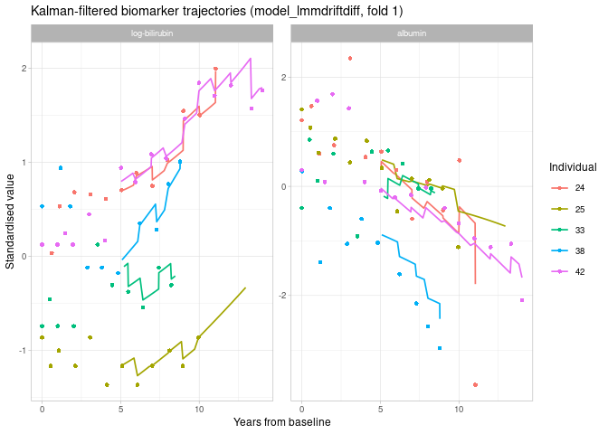

```r
## py_to_r() converts a pandas DataFrame to an R data frame.
## cv_results[["model_lmmdriftdiff"]]$fold_pred is an R list of data frames
## (one per fold); the first element is the fold-1 test predictions.
pred1    <- py_to_r(cv_results[["model_lmmdriftdiff"]]$fold_pred[[1]])
pred1_dt <- as.data.table(pred1)

## Select two individuals who had events and three who were censored.
ids_event <- head(pred1_dt[event == 1, unique(id)], 2)
ids_cens  <- head(setdiff(pred1_dt[event == 0, unique(id)], ids_event), 3)
ids_show  <- unique(c(ids_event, ids_cens))

kalman_long <- melt(
  pred1_dt[id %in% ids_show, .(id, tstart, logBili, albumin)],
  id.vars       = c("id", "tstart"),
  variable.name = "biomarker",
  value.name    = "filtered"
)

obs_long <- melt(
  as.data.table(dataLong_r)[id %in% ids_show, .(id, Time, logBili, albumin)],
  id.vars       = c("id", "Time"),
  variable.name = "biomarker",
  value.name    = "observed"
)

kalman_long[, id := factor(id)]
obs_long[,   id := factor(id)]

ggplot() +
  geom_line(data  = kalman_long,
            aes(x = tstart, y = filtered, colour = id),
            linewidth = 0.6) +
  geom_point(data = obs_long,
             aes(x = Time, y = observed, colour = id),
             size = 1.4, shape = 16) +
  facet_wrap(~ biomarker, scales = "free_y",
             labeller = labeller(biomarker = c(logBili = "log-bilirubin",
                                               albumin  = "albumin"))) +
  labs(x     = "Years from baseline",
       y     = "Standardised value",
       colour = "Individual",
       title  = "Kalman-filtered biomarker trajectories (model_lmmdriftdiff, fold 1)") +
  theme(legend.position = "right")
```

## Per-fold predictive performance

`cv_results[["model_lmm"]]$fold_stats` is a Python list of dicts, which reticulate converts to an R list of named lists. Standard R functions (`mapply`, `sapply`, etc.) work directly on this structure.

```r
get_fold_table <- function(model_name) {
  stats_list <- cv_results[[model_name]]$fold_stats
  rows <- mapply(function(s, i) {
    data.frame(
      Fold          = i,
      Observed      = s[["Observed"]],
      Predicted     = round(s[["Predicted"]], 1),
      `Log score`   = round(s[["Log score"]], 2),
      `C-statistic` = round(s[["C-statistic"]], 3),
      check.names   = FALSE
    )
  }, stats_list, seq_along(stats_list), SIMPLIFY = FALSE)
  do.call(rbind, rows)
}

fold_lmm  <- get_fold_table("model_lmm")
fold_full <- get_fold_table("model_lmmdriftdiff")

kable(fold_lmm,
      caption = "model_lmm: per-fold predictive performance",
      align   = "r") |>
  kable_styling(bootstrap_options = c("striped", "hover"), full_width = FALSE)
```

model_lmm: per-fold predictive performance

| Fold | Observed | Predicted | Log score | C-statistic |
| --- | --- | --- | --- | --- |
| 1 | 8 | 13.5 | -37.62 | 0.893 |
| 2 | 16 | 9.1 | -64.09 | 0.853 |
| 3 | 18 | 11.9 | -73.24 | 0.806 |
| 4 | 9 | 22.0 | -48.57 | 0.836 |

```r
kable(fold_full,
      caption = "model_lmmdriftdiff: per-fold predictive performance",
      align   = "r") |>
  kable_styling(bootstrap_options = c("striped", "hover"), full_width = FALSE)
```

model_lmmdriftdiff: per-fold predictive performance

| Fold | Observed | Predicted | Log score | C-statistic |
| --- | --- | --- | --- | --- |
| 1 | 8 | 10.7 | -34.28 | 0.897 |
| 2 | 16 | 7.8 | -58.43 | 0.857 |
| 3 | 18 | 13.2 | -66.07 | 0.852 |
| 4 | 9 | 28.3 | -50.23 | 0.852 |

## Pooled cross-validated performance

```r
make_row <- function(model_name) {
  s <- cv_results[[model_name]]$pooled
  data.frame(
    Model          = model_name,
    Observed       = s[["Observed"]],
    Predicted      = round(s[["Predicted"]], 1),
    `Person-years` = round(s[["Person-years"]], 0),
    `Log score`    = round(s[["Log score"]], 2),
    `C-statistic`  = round(s[["C-statistic"]], 3),
    check.names    = FALSE
  )
}

perf_table <- rbind(make_row("model_lmm"),
                    make_row("model_lmmdriftdiff"))

kable(perf_table,
      caption = paste("Pooled 4-fold cross-validated predictive performance",
                      "(landmark time 5 years, follow-up to 15 years)"),
      align   = c("l", rep("r", 5))) |>
  kable_styling(bootstrap_options = c("striped", "hover"), full_width = FALSE) |>
  column_spec(6, bold = TRUE)
```

Pooled 4-fold cross-validated predictive performance (landmark time 5 years, follow-up to 15 years)

| Model | Observed | Predicted | Person-years | Log score | C-statistic |
| --- | --- | --- | --- | --- | --- |
| model_lmm | 51 | 56.5 | 707 | -223.52 | 0.830 |
| model_lmmdriftdiff | 51 | 60.0 | 707 | -209.01 | 0.852 |

## C-statistic by fold

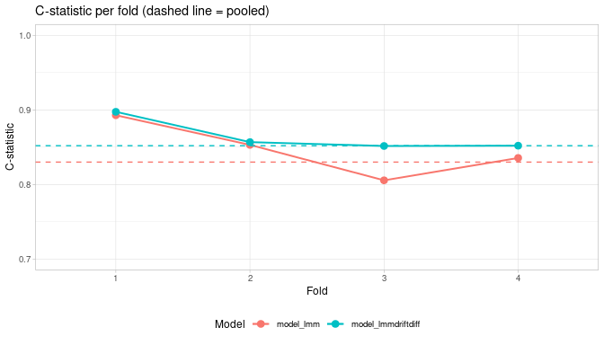

```r
fold_df <- rbind(
  data.frame(model = "model_lmm",
             fold  = 1:4,
             C     = sapply(cv_results[["model_lmm"]]$fold_stats,
                            `[[`, "C-statistic")),
  data.frame(model = "model_lmmdriftdiff",
             fold  = 1:4,
             C     = sapply(cv_results[["model_lmmdriftdiff"]]$fold_stats,
                            `[[`, "C-statistic"))
)

ggplot(fold_df, aes(x = factor(fold), y = C, colour = model, group = model)) +
  geom_line(linewidth = 0.7) +
  geom_point(size = 2.5) +
  geom_hline(data     = perf_table,
             aes(yintercept = `C-statistic`, colour = Model),
             linetype  = "dashed",
             linewidth = 0.5) +
  scale_y_continuous(limits = c(0.7, 1.0)) +
  labs(x      = "Fold",
       y      = "C-statistic",
       colour = "Model",
       title  = "C-statistic per fold (dashed line = pooled)") +
  theme(legend.position = "bottom")
```

The C-statistic and log-score are both computed over all person-time intervals from the landmark time to exit, treating each interval as an independent binary observation (event / no event). The C-statistic is the area under the ROC curve of the predicted interval-event probability; the log-score is the sum of the Bernoulli log-likelihoods.

# Methods summary

The two-step procedure is:

1. **LGSSM** — a continuous-time SDE
   $$dX(t) = (AX(t) + b)\,dt + G\,dW(t), \quad y_t = x_t + v_t, \quad v_t \sim N(0,R)$$
   is fitted to the longitudinal data by MAP inference (NumPyro SVI with an `AutoDelta` guide and `ClippedAdam` optimiser). Discrete-time transition matrices $A_d(\Delta t) = \exp(A\,\Delta t)$ and process noise $Q_d(\Delta t)$ are obtained via the Van Loan method, implemented with a fixed-order degree-7 Padé matrix exponential that contains no data-dependent conditionals and therefore compiles efficiently under JAX.
2. **Kalman filter** — implemented in JAX using `jax.lax.scan` over time steps and `jax.vmap` over individuals. Filtered state means $\hat x_t$ are extracted for each person-time interval. In the test fold, biomarker observations after the landmark time are withheld; the filter propagates the last observed state forward using only the SDE dynamics.
3. **Poisson GLM** — the log-hazard is modelled as
   $$\log \lambda_i(t) = \beta_0 + \beta_t t + \beta_x \hat x_i(t) + \beta_z z_i$$
   where $z_i$ are time-invariant covariates. Fitted by MAP using QR decomposition of the design matrix for numerical stability.